# 第11回 標準誤差・t 値・仮説検定・信頼区間

## 出力表の下限 95% と上限 95%

[figure not shown]

下限 95% −3.8374・上限 95% −0.1626。○ が並ぶ範囲と同じ

## 区間と検定の表裏

- **0 が区間の外**：基準 0 は捨てられた
- **だから**：P-値は 5% 以下（5 人 0.0405）
- **区間は幅も言う**：−1 くらいでも −3 くらいでも、  
  データとは食い違わない
- **5 人しかいない**：だから幅が広い

## よくある失敗 95% の読み

**取り違え**  
本当の傾きが 95% の確率で  
この範囲に入る

**正しい読み**  
データと食い違わない  
傾きの範囲

本当の傾きは 1 つ。95% は、区間の作り方が当たる割合  
5 人を作り直すたびに区間を作ると  
1000 回のうち 951 回は本当の傾き −2 を含む

## 5 人の基準を替えた t

1. **基準**：シート「5人」の  
   G6 に −1
2. **式**：G7 に `=(L18-G6)/M18`  
   → −1.7321
3. **替える**：G6 を 0、−5 に  
   → G7 は −3.4641、5.1962

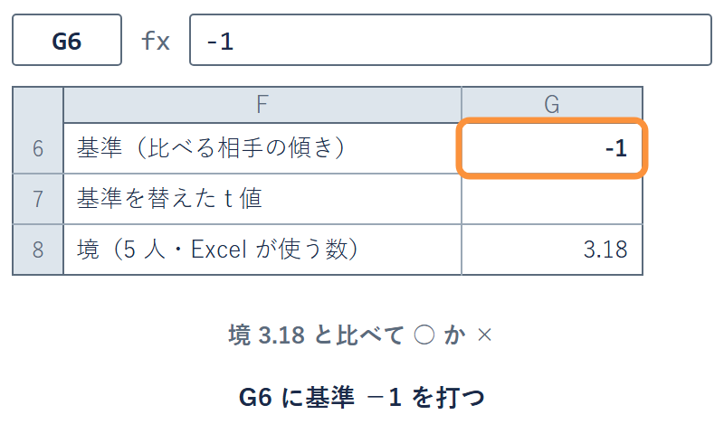

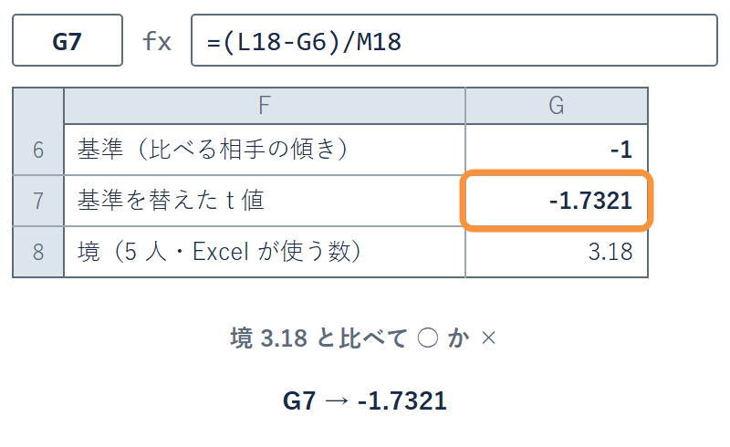

[figure not shown]

✋ 動画を止めて ①〜③ を進め、G8 の 3.18 と比べたら再生に戻る

## 36 年の 95% 信頼区間

[figure not shown]

今度は 36 年。境は約 2.03 で −1.133〜−0.585。0 は区間の外  
境を 2 にすると −1.129〜−0.589（点が多いときの暗算の目安）

## 36 年の区間の式

1. **境**：シート「失業率と物価」の  
   G6 の 2（配ってある）
2. **下限**：G7 に `=L18-G6*M18`  
   → −1.1287
3. **上限**：G8 に `=L18+G6*M18`  
   → −0.5889

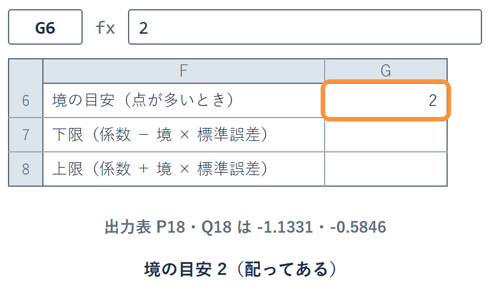

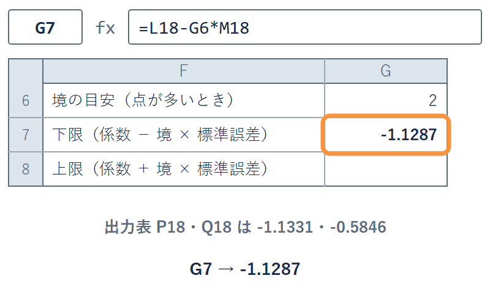

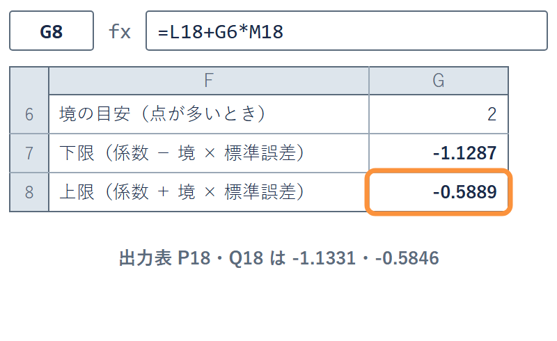

✋ 動画を止めて ①〜③ を進め、G7 と G8 が出たら再生に戻る

## たしかめ 2013〜2019 年の区間

2013〜2019 年の 7 年だけで引いた傾き  
その 95% 信頼区間は、0 をまたぐか

**1 またがない**

**2 またぐ**

1 つ決めてから先へ。答えは、このトピックの中で出す

## 演習 11-4 7 年の信頼区間

演習 11-4

2013〜2019 年の区間は、0 をまたぐか

1. **出力表**：演習 11-3 で K41 から右に出した表（**実データ** 2013〜2019 年）
2. **読む**：傾きの行の下限 95%（P58）と上限 95%（Q58）
3. **考える**：0 は区間の内側か外側か
4. **答え**：G15 に「またぐ（下限〜上限）」の形で

✋ 動画を止めて演習 11-4 を進め（11-3 がまだなら先に）、G15 を書いたら再生に戻る

## 期間で変わる区間

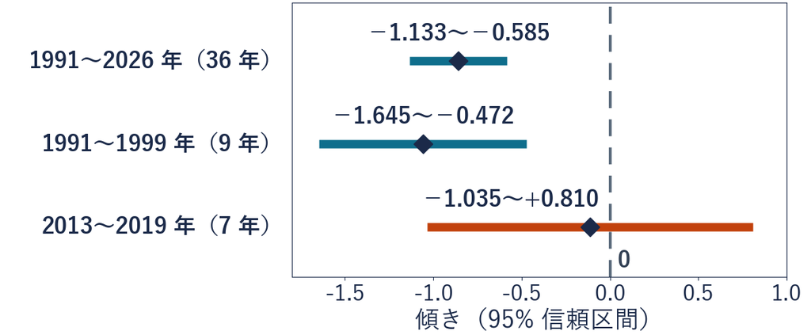

0 をまたぐのは 2013〜2019 年だけ。たしかめの答えは 2 番

## 95% と 5% の関係

[figure not shown]

基準の候補を 1 つずつ 5% の検定にかけ、捨てない ○ を並べる  
○ の並び ＝ 95% 信頼区間（100% − 5%）。0 が外 ⇔ P-値 5% 以下

## Q&A 信頼区間

Q1 自分の式と出力表で、最後の桁が違う

境を 2 と丸めたから。出力表は **2.03** を使う

Q2 右の「下限 95.0%」の列は何か

「有意水準」を 95 以外にしたときだけ違う数が入る列  
ふだんは同じ数。**左の 2 列**を読めばよい  
95 は区間の信頼水準。100 から 5 を引いた数（5 は検定の有意水準）

Q3 区間が 0 をまたいだ

関係が無いとは言えない。**このデータでは傾きを絞り込めなかった**

## この回のまとめ

用語

**標準誤差**データを作り直したときの、傾きの散らばりの幅

**t 値**傾きが基準から、標準誤差の何個分離れているか

**仮説検定**「関係なし」と仮定して、珍しさを測る

**信頼区間**データと食い違わない傾きを、幅で言う

傾きの数には、信頼区間を添えて言う  
自習時間を説明するのに、バイト日数のほかにも数を 2 つ、  
3 つと増やしたら、どうなるか